# HW2-chapter8

Guangjin Zhou

February 26, 2019

## Libraries

```r
library(rpart);library(ISLR);library(dplyr);library(tree)
```

## Orange juice dataset

```r
dim(OJ); names(OJ)
```

```
## [1] 1070   18
```

```
##  [1] "Purchase"       "WeekofPurchase" "StoreID"        "PriceCH"
##  [5] "PriceMM"        "DiscCH"         "DiscMM"         "SpecialCH"
##  [9] "SpecialMM"      "LoyalCH"        "SalePriceMM"    "SalePriceCH"
## [13] "PriceDiff"      "Store7"         "PctDiscMM"      "PctDiscCH"
## [17] "ListPriceDiff"  "STORE"
```

Variable codebook:

WeekofPurchase: Week of purchase

StoreID: Store ID

PriceCH: Price charged for CH (Citrus Hill)

PriceMM: Price charged for MM (Minute Maid)

DiscCH:Discount offered for CH (Citrus Hill)

DiscMM:Discount offered for MM (Minute Maid)

SpecialCH: Indicator of special on CH (Citrus Hill)

SpecialMM: Indicator of special on MM (Minute Maid)

LoyalCH:Customer brand loyalty for CH (Citrus Hill)

SalePriceMM: Sale price for MM (Minute Maid)

SalePriceCH: Sale price for CH (Citrus Hill)

PriceDiff: Sale price of MM (Minute Maid) less sale price of CH (Citrus Hill)

Store7: A factor with levels No and Yes indicating whether the sale is at Store 7

PctDiscMM: Percentage discount for MM (Minute Maid)

PctDiscCH: Percentage discount for CH (Citrus Hill)

ListPriceDiff: List price of MM (Minute Maid) less list price of CH (Citrus Hill)

STORE: 5 possible stores the sale occured

# 9.

This problem involves the OJ data set which is part of the ISLR package.

## (a) Create a training set containing a random sample of 800 observations,and a test set containing the remaining observations.

### A random sampling function

```r
randomRows = function(df,n){
   return(df[sample(nrow(df),n),])
}
```

### Training and test dataset

```r
OJ$ID <- seq.int(nrow(OJ));names(OJ)
```

```
##  [1] "Purchase"       "WeekofPurchase" "StoreID"        "PriceCH"
##  [5] "PriceMM"        "DiscCH"         "DiscMM"         "SpecialCH"
##  [9] "SpecialMM"      "LoyalCH"        "SalePriceMM"    "SalePriceCH"
## [13] "PriceDiff"      "Store7"         "PctDiscMM"      "PctDiscCH"
## [17] "ListPriceDiff"  "STORE"          "ID"
```

```r
OJ_train<-randomRows(OJ, 800);dim(OJ_train)
```

```
## [1] 800  19
```

```r
OJ_test<-dplyr::anti_join(OJ, OJ_train, by="ID"); dim(OJ_test)
```

```
## [1] 270  19
```

```r
OJ_train$ID<-NULL
OJ_test$ID<-NULL
```

## (b) Fit a tree to the training data, with Purchase as the response and the other variables as predictors.

Use the summary() function to produce summary statistics about the tree, and describe the results obtained. What is the training error rate? How many terminal nodes does the tree have?

## tree by rpart

```r
OJ.tree1<-rpart(Purchase ~ ., data=OJ_train);summary(OJ.tree1)
```

```
## Call:
## rpart(formula = Purchase ~ ., data = OJ_train)
##   n= 800
##
##           CP nsplit rel error    xerror       xstd
## 1 0.48026316      0 1.0000000 1.0000000 0.04516053
## 2 0.02412281      1 0.5197368 0.5361842 0.03747528
## 3 0.01480263      4 0.4473684 0.5164474 0.03695190
## 4 0.01000000      8 0.3881579 0.5361842 0.03747528
##
## Variable importance
##        LoyalCH  ListPriceDiff      PriceDiff    SalePriceMM WeekofPurchase
##             50              8              8              7              6
##        PriceMM         DiscMM      PctDiscMM        PriceCH        StoreID
##              5              5              5              3              2
##      SpecialMM
##              1
##
## Node number 1: 800 observations,    complexity param=0.4802632
##   predicted class=CH  expected loss=0.38  P(node) =1
##     class counts:   496   304
##    probabilities: 0.620 0.380
##   left son=2 (502 obs) right son=3 (298 obs)
##   Primary splits:
##       LoyalCH   < 0.482304  to the right, improve=126.51390, (0 missing)
##       StoreID   < 3.5       to the right, improve= 36.93134, (0 missing)
##       PriceDiff < 0.165     to the right, improve= 24.46541, (0 missing)
##       STORE     < 0.5       to the left,  improve= 20.57672, (0 missing)
##       Store7    splits as  RL, improve= 20.57672, (0 missing)
##   Surrogate splits:
##       PriceMM        < 1.89      to the right, agree=0.642, adj=0.040, (0 split)
##       WeekofPurchase < 229.5     to the right, agree=0.641, adj=0.037, (0 split)
##       StoreID        < 3.5       to the right, agree=0.640, adj=0.034, (0 split)
##       DiscMM         < 0.57      to the left,  agree=0.634, adj=0.017, (0 split)
##       PctDiscMM      < 0.264375  to the left,  agree=0.634, adj=0.017, (0 split)
##
## Node number 2: 502 observations,    complexity param=0.02412281
##   predicted class=CH  expected loss=0.1633466  P(node) =0.6275
##     class counts:   420    82
##    probabilities: 0.837 0.163
```

[output cut: 145 more lines]

```
##       PriceMM       < 2.11      to the right, agree=0.794, adj=0.548, (0 split)
##       SalePriceMM   < 2.105     to the right, agree=0.779, adj=0.516, (0 split)
##       PriceCH       < 1.825     to the right, agree=0.765, adj=0.484, (0 split)
##       PriceDiff     < 0.31      to the right, agree=0.721, adj=0.387, (0 split)
##       ListPriceDiff < 0.255     to the right, agree=0.706, adj=0.355, (0 split)
##
## Node number 50: 37 observations
##   predicted class=CH  expected loss=0.3513514  P(node) =0.04625
##     class counts:    24    13
##    probabilities: 0.649 0.351
##
## Node number 51: 31 observations
##   predicted class=MM  expected loss=0.3548387  P(node) =0.03875
##     class counts:    11    20
##    probabilities: 0.355 0.645
```

## Use tree library

```r
OJ.tree2<- tree(Purchase ~ ., data=OJ_train); summary(OJ.tree2)
```

```
##
## Classification tree:
## tree(formula = Purchase ~ ., data = OJ_train)
## Variables actually used in tree construction:
## [1] "LoyalCH"       "SalePriceMM"   "ListPriceDiff" "DiscMM"
## Number of terminal nodes:  7
## Residual mean deviance:  0.7687 = 609.5 / 793
## Misclassification error rate: 0.17 = 136 / 800
```

## (c) Type in the name of the tree object in order to get a detailed text output. Pick one of the terminal nodes, and interpret the information displayed.

```r
OJ.tree1;
```

```
## n= 800
##
## node), split, n, loss, yval, (yprob)
##       * denotes terminal node
##
##  1) root 800 304 CH (0.62000000 0.38000000)
##    2) LoyalCH>=0.482304 502  82 CH (0.83665339 0.16334661)
##      4) LoyalCH>=0.7645725 262  11 CH (0.95801527 0.04198473) *
##      5) LoyalCH< 0.7645725 240  71 CH (0.70416667 0.29583333)
##       10) ListPriceDiff>=0.235 148  20 CH (0.86486486 0.13513514) *
##       11) ListPriceDiff< 0.235 92  41 MM (0.44565217 0.55434783)
##         22) DiscMM< 0.15 50  19 CH (0.62000000 0.38000000) *
##         23) DiscMM>=0.15 42  10 MM (0.23809524 0.76190476) *
##    3) LoyalCH< 0.482304 298  76 MM (0.25503356 0.74496644)
##      6) LoyalCH>=0.280875 135  54 MM (0.40000000 0.60000000)
##       12) PriceDiff>=0.05 75  33 CH (0.56000000 0.44000000)
##         24) LoyalCH< 0.303104 7   0 CH (1.00000000 0.00000000) *
##         25) LoyalCH>=0.303104 68  33 CH (0.51470588 0.48529412)
##           50) WeekofPurchase>=255.5 37  13 CH (0.64864865 0.35135135) *
##           51) WeekofPurchase< 255.5 31  11 MM (0.35483871 0.64516129) *
##       13) PriceDiff< 0.05 60  12 MM (0.20000000 0.80000000) *
##      7) LoyalCH< 0.280875 163  22 MM (0.13496933 0.86503067) *
```

```r
OJ.tree2
```

```
## node), split, n, deviance, yval, (yprob)
##       * denotes terminal node
##
##  1) root 800 1063.00 CH ( 0.62000 0.38000 )
##    2) LoyalCH < 0.482304 298  338.40 MM ( 0.25503 0.74497 )
##      4) LoyalCH < 0.0616725 67   17.99 MM ( 0.02985 0.97015 ) *
##      5) LoyalCH > 0.0616725 231  289.70 MM ( 0.32035 0.67965 )
##       10) SalePriceMM < 2.04 123  121.40 MM ( 0.19512 0.80488 ) *
##       11) SalePriceMM > 2.04 108  149.10 MM ( 0.46296 0.53704 ) *
##    3) LoyalCH > 0.482304 502  447.00 CH ( 0.83665 0.16335 )
##      6) LoyalCH < 0.764572 240  291.50 CH ( 0.70417 0.29583 )
##       12) ListPriceDiff < 0.235 92  126.40 MM ( 0.44565 0.55435 )
##         24) DiscMM < 0.15 50   66.41 CH ( 0.62000 0.38000 ) *
##         25) DiscMM > 0.15 42   46.11 MM ( 0.23810 0.76190 ) *
##       13) ListPriceDiff > 0.235 148  117.20 CH ( 0.86486 0.13514 ) *
##      7) LoyalCH > 0.764572 262   91.28 CH ( 0.95802 0.04198 ) *
```

## (d) Create a plot of the tree, and interpret the results.

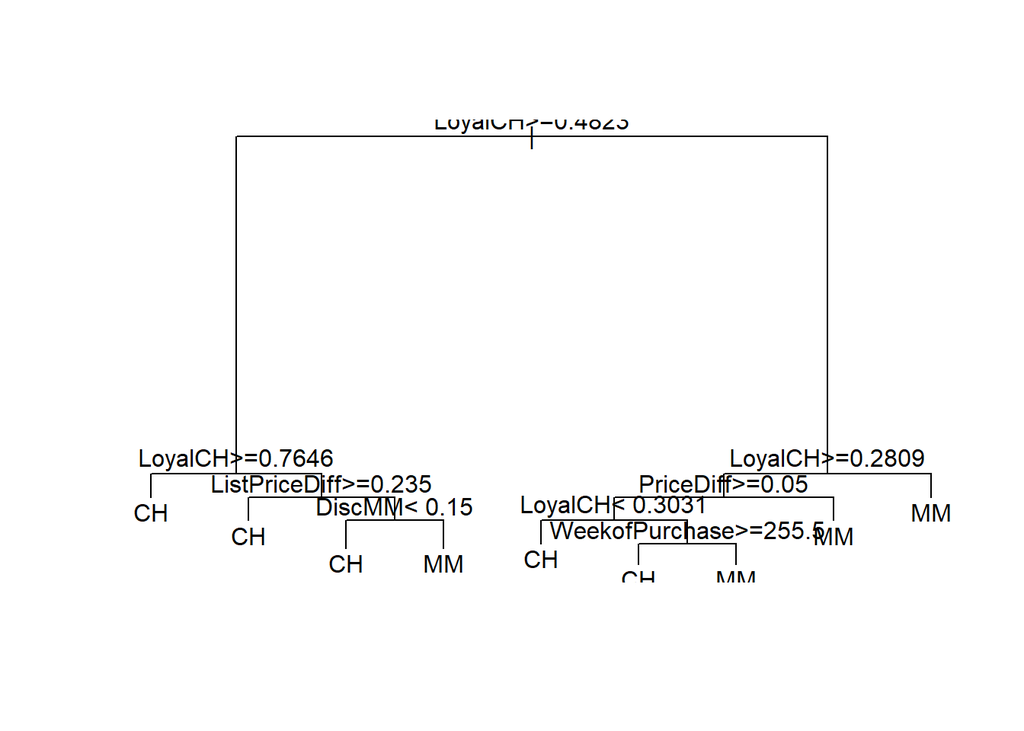

```r
plot(OJ.tree1);text(OJ.tree1)
```

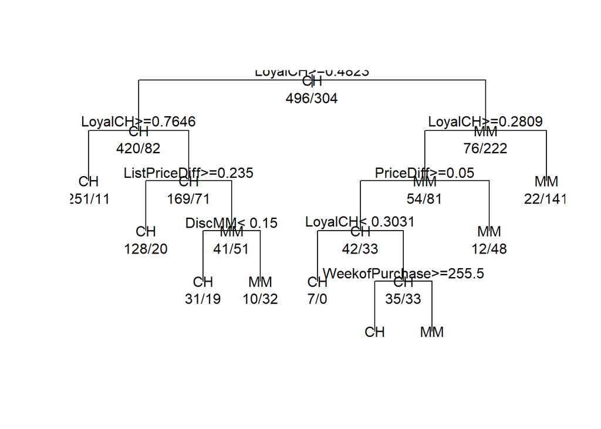

```r
plot(OJ.tree1, uniform=T); text(OJ.tree1, all=T, use.n=T)
```

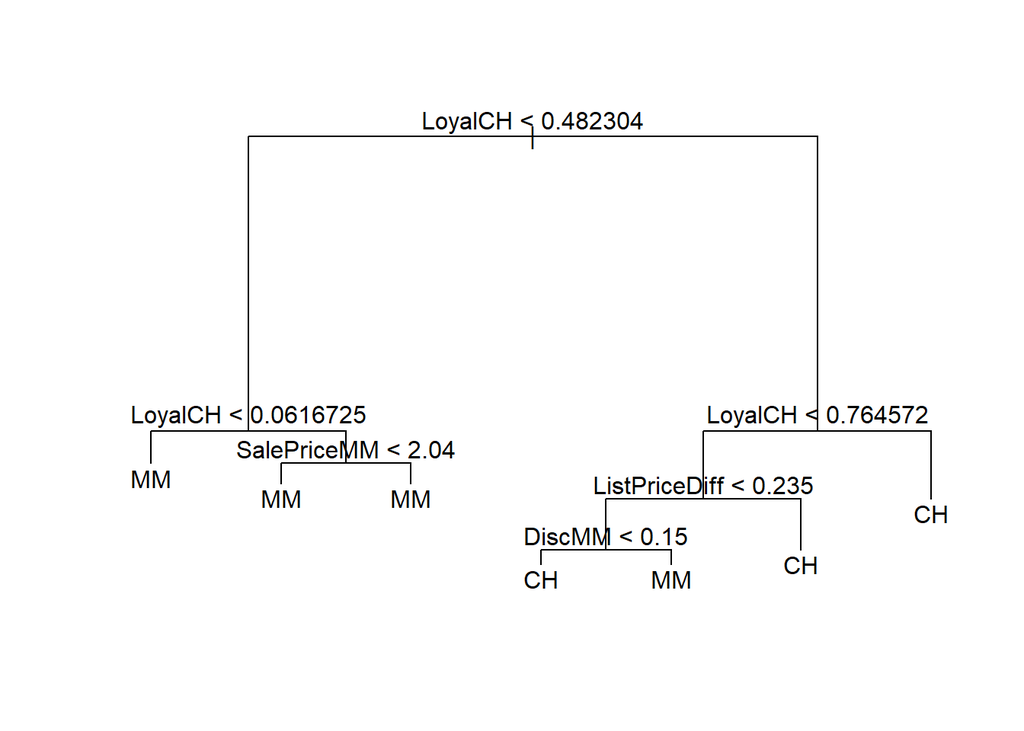

```r
plot(OJ.tree2);text(OJ.tree2)
```

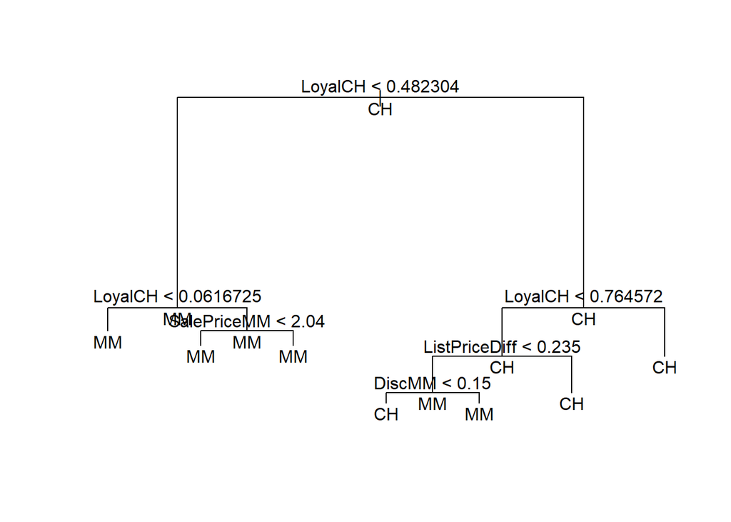

```r
plot(OJ.tree2, uniform=T); text(OJ.tree2, all=T, use.n=T)
```

LoyalCH is the most important variable of the tree, Two different tree modesl show the first node is LoyalCH. Both trees also predicts MM. The tree decision is also depends on the value of PriceDiff at some point.

## (e) Predict the response on the test data, and produce a confusion matrix comparing the test labels to the predicted test labels. What is the test error rate?

```r
oj.pred1 = predict(OJ.tree1, OJ_test, type = "class")
table(OJ_test$Purchase, oj.pred1)
```

```
##     oj.pred1
##       CH  MM
##   CH 138  19
##   MM  31  82
```

## (f) Apply the cv.tree() function to the training set in order to determine the optimal tree size.

I picked tree 2 to do prune function

```r
cv.oj1 <- cv.tree(OJ.tree2, FUN = prune.tree); summary(cv.oj1)
```

```
##        Length Class  Mode
## size   7      -none- numeric
## dev    7      -none- numeric
## k      7      -none- numeric
## method 1      -none- character
```

## (g) Produce a plot with tree size on the x-axis and cross-validated classification error rate on the y-axis.

I picked tree 2 to produce the plot.

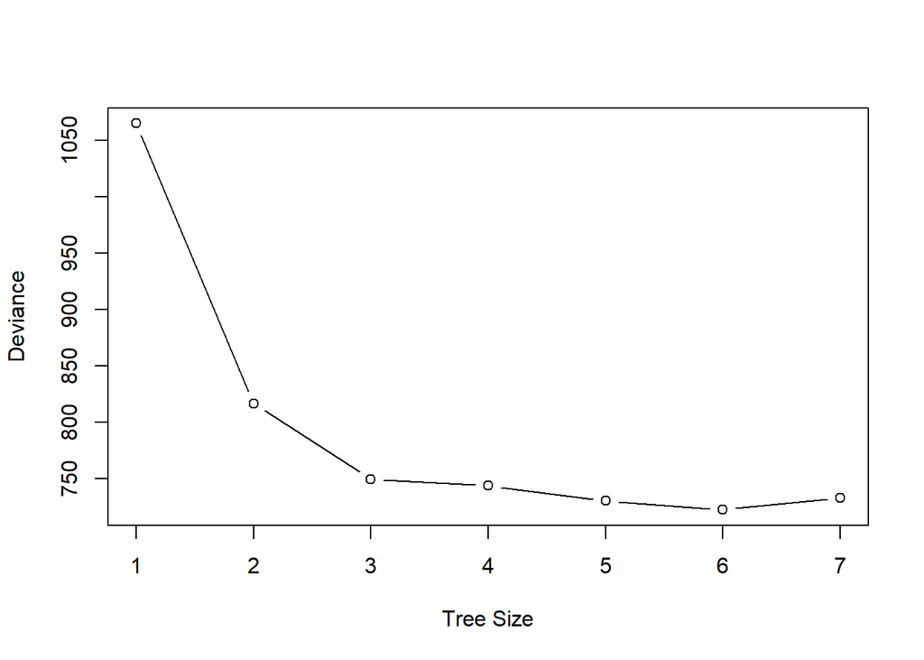

```r
plot(cv.oj1$size, cv.oj1$dev, type = "b", xlab = "Tree Size", ylab = "Deviance")
```

## (i) Produce a pruned tree corresponding to the optimal tree size obtained using cross-validation.

```r
oj.pruned <- prune.tree(OJ.tree2, best = 7); summary(oj.pruned)
```

```
##
## Classification tree:
## tree(formula = Purchase ~ ., data = OJ_train)
## Variables actually used in tree construction:
## [1] "LoyalCH"       "SalePriceMM"   "ListPriceDiff" "DiscMM"
## Number of terminal nodes:  7
## Residual mean deviance:  0.7687 = 609.5 / 793
## Misclassification error rate: 0.17 = 136 / 800
```

If cross-validation does not lead to selection of a pruned tree, then create a pruned tree with five terminal nodes.

## (j) Compare the training error rates between the pruned and unpruned trees. Which is higher?

```r
summary(OJ.tree2)
```

```
##
## Classification tree:
## tree(formula = Purchase ~ ., data = OJ_train)
## Variables actually used in tree construction:
## [1] "LoyalCH"       "SalePriceMM"   "ListPriceDiff" "DiscMM"
## Number of terminal nodes:  7
## Residual mean deviance:  0.7687 = 609.5 / 793
## Misclassification error rate: 0.17 = 136 / 800
```